# 拉格朗日对偶、KKT条件——以LASSO为例

Yann

2019-04-07

# 0.介绍

数学优化

# 1.拉格朗日对偶

## 1.1.拉格朗日函数

我们考虑标准形式的优化问题：
$$\begin{aligned}
& \min \ \ f_0(x) \\
&\ \text{s.t.} \ \ \ f_i(x) \le 0, \ \ i=1,\cdots,m \\
& \ \ \ \ \ \ \ \ h_i(x)=0, \ \ i=1,\cdots,p
\end{aligned}
\tag{1.1}$$
其中自变量$x\in\mathbf{R}^n$。设问题的定义域$\mathcal{D}=\bigcap_{i=0}^m\mathbf{dom}\ f_i \cap \bigcap_{i=0}^p\mathbf{dom}\ h_i$为非空集合（$\mathbf{dom}\ f$表示$f$的定义域），该优化问题的最优值为$p^*$。对于其他形式的优化问题，我们可以通过变换转化为该形式。

接着我们就可以定义问题（1.1）的**拉格朗日函数**（*Lagrangian* ）$L:\mathbf{R}^n\times \mathbf{R}^m \times \mathbf{R}^p\to \mathbf{R}$ 为

$$L(x,\lambda,\nu)=f_0(x)+\sum_{i=1}^{m}\lambda_i f_i(x)+\sum_{i=1}^{p}\nu_i h_i(x)$$
形式上它可以看成目标函数与约束条件的加权和，定义域为$\mathbf{dom}\ L=\mathcal{D}\times \mathbf{R}^m\times \mathbf{R}^p$ 。$\lambda_i$ 称为第$i$个不等式约束$f_i(x) \le 0$对应的**拉格朗日乘子**（*Lagrange multiplier*）；类似的$\nu_i$称为第$i$个等式约束$h_i(x)=0$的拉格朗日乘子。以它们各自为分量的向量$\lambda$和$\nu$称为**对偶变量**（*dual variables*）或问题（1.1）的**拉格朗日乘子向量**（*Lagrange multiplier vectors* ）。

## 1.2.拉格朗日对偶函数

**拉格朗日对偶函数**（或简称**对偶函数**）$g:\mathbf{R}^m \times \mathbf{R}^p\to\mathbf{R}$ 是由拉格朗日函数$L$关于$x$求极小值得到的，定义为：对任意$\lambda \in\mathbf{R}^m, \nu \in \mathbf{R}^p$，有
$$g(\lambda,\nu)=\inf_{x\in\mathcal{D}}{L(x,\lambda,\nu)}=\inf_{x\in\mathcal{D}}{\left( f_0(x)+\sum_{i=1}^{m}\lambda_i f_i(x)+\sum_{i=1}^{p}\nu_i h_i(x) \right)}.$$
如果$L$关于$x$无下界，则对偶函数取值为$-\infty$。对偶函数有个很好的性质，无论$f_i,h_i$是否为凸函数，$g$都是凹函数。这是因为$L$是关于$(\lambda,\nu)$的*仿射函数*[^1]，所以关于$x$逐点取下确界后还是凹函数[^2]。

我们可以利用对偶函数找到问题（1.1）最优值$p^*$的下界：对任意的$\lambda\succeq0$（表示$\lambda$每个分量$\lambda_i\ge0$）和$\nu$，我们有
$$g(\lambda,\nu)\le p^* \tag{1.2}$$
这是由于对问题（1.1）的任何**可行解**$\tilde{x}$（满足约束条件的解），有下式成立
$$g(\lambda,\nu)=\inf_{x\in\mathcal{D}}{L(x,\lambda,\nu)}\le L(\tilde{x},\lambda,\nu)\le f_0(\tilde{x})$$
因为$\tilde{x}$的可行性保证了$L(\tilde{x},\lambda,\nu)$中的$\sum_{i=1}^{m}\lambda_i f_i(\tilde{x})\le0,\ \sum_{i=1}^{p}\nu_i h_i(\tilde{x}) =0$。
我们找到了$p^*$的下界，但如果这个下界是$-\infty$，依然没有什么意义。因此我们定义
$$\mathbf{dom}\ g=\{(\lambda,\nu):g(\lambda,\nu)>-\infty\}$$
并称$\mathbf{dom}\ g$中满足$\lambda\succeq 0$的$(\lambda,\nu)$是**对偶可行**（*dual feasible*）的。

## 1.3.拉格朗日对偶问题

我们已经找到了问题（1.1）最优值$p^*$的一个下界，它是$(\lambda,\nu)$的函数。显然，最大的那个下界是我们最感兴趣的，因为它最接近$p^*$，这也是引入**拉格朗日对偶问题**（*Lagrange dual problem*）的动机，问题（1.1）的拉格朗日对偶问题定义为
$$\begin{aligned}
& \text{max}\ \ g(\lambda, \nu) \\
& \text{s.t.} \ \ \ \ \lambda\succeq 0
\end{aligned}
\tag{1.3}$$
对应的，我们称问题（1.1）为**原问题**（*primal problem*）。根据前面定义，满足对偶可行的$(\lambda,\nu)$是对偶问题（1.3）的可行解。我们称解$(\lambda^*,\nu^*)$是**对偶最优解**（*dual optimal*）或**最优拉格朗日乘子**（*optimal Lagrange multipliers*），若它是对偶问题（1.3）的最优解， 并记对偶问题最优值为$d^*$。

我们可以看到无论原问题（1.1）是否是凸优化问题（凸优化问题严格定义见1.4节），对偶问题（1.3）都是一个凸优化问题（因为$g(\lambda,\nu)$是关于$(\lambda,\nu)$的凹函数）。

## 1.4.弱对偶性、强对偶性和Slater定理

根据1.3节，我们已经知道对偶问题（1.3）的最优值$d^*$是原问题（1.1）最优值$p^*$的一个最“好”下界（依然是一个下界），所以很显然有下面这个不等式成立
$$d^*\le p^* \tag{1.4}$$
这个简单而又重要的不等式便称为**弱对偶性**（*weak duality*）（$d^*$和$p^*$可能为无穷）。

我们定义差值$p^*-d^*$是原问题的**最优对偶间隙**（*optimal duality gap*），它度量了原问题最优值与由对偶问题得到的最大下界之间的差距，根据弱对偶性可知对偶间隙总是非负的。
类似的，若等式
$$d^*= p^* \tag{1.5}$$
成立，即对偶间隙为$0$，则称**强对偶性**（*strong duality*）成立，也就是说我们通过对偶问题找到的最大下界就是原问题的最优值。

对于一般的优化问题，强对偶性一般不成立，但如果原问题是凸问题时，通常（并不一定）强对偶性是成立的。为此，我们先定义**凸优化问题**（*convex optimization problems*），它是指形如
$$\begin{aligned}
& \text{min} \ \ f_0(x) \\
& \text{s.t.} \ \ \ f_i(x) \le 0, \ \ i=1,\cdots,m \\
& \ \ \ \ \ \ \ \ a_i^Tx=b, \ \ i=1,\cdots,p \ \ \text{（或写成}Ax=b\text{）}
\end{aligned}
\tag{1.6}$$
的优化问题，其中$f_i,\ \ i=1,\cdots,m$为凸函数。对比问题（1.1），可以发现凸优化问题有三个附加要求：

- 目标函数必须是凸的，
- 不等式约束函数必须是凸的，
- 等式约束函数$h_i(x)=a_i^Tx-b$是仿射函数。

我们可以注意到：凸优化问题的*可行集*[^3]是凸的，因为它是问题的定义域
$$\mathcal{D}=\bigcap_{i=0}^m{\mathbf{dom}\ f_i}$$
（是一个凸集）与$m$个（凸的）*下水平集*[^4]$\{x|f_i(x)\le 0\}$以及$p$个超平面$\{x|a_i^Tx=b\}$（凸集）的交集。凸优化问题一个基本性质为：任意局部最优解也是全局最优解，所以对于凸优化问题我们寻找到一个局部最优解即可。

有很多研究成果给出了强对偶性成立的条件，其中较为简单的一种是**Slater条件**：
存在一点$x\in \mathbf{int}\ \mathcal{D}$（表示$\mathcal{D}$的**内部**，即$\mathcal{D}$所有内点组成的集合）使得下式成立：
$$\begin{aligned} f_i(x)&<0,\ \ i=1,\cdots,m \\ Ax&=b. \end{aligned} \tag{1.7}$$
满足上述条件的点也称为**严格可行**（*strictly feasible*），因为不等式是严格成立的。

**Slater定理**：若原问题是凸问题，且Slater条件成立，则强对偶性成立。（证明见参考文献1）

当不等式约束函数$f_i$中有一些是仿射函数时，我们可以得到弱化的Slater条件：若$f_1,\cdots,f_k,\ k\le m$是仿射函数，且存在一点$x\in \mathbf{relint}\ \mathcal{D}$[^5]使得下式成立：
$$\begin{aligned} f_i(x)&\le 0,\ \ i=1,\cdots,k \\ f_i(x)&<0,\ i=k+1,\cdots,m \\ Ax&=b. \end{aligned} \tag{1.8}$$
也就是说仿射不等式约束不需要严格成立。将Slater定理中的Slater条件用用弱化的版本替代后，定理依然成立。

我们可以注意到，当所有约束条件都是仿射等式或不等式（则约束函数的定义域都是$\mathbf{R}^n$）且$f_0$的定义域是开集时，那么$\mathcal{D}$也是开集（就是$\mathbf{dom}\ f_0$，此时$\mathbf{int}\ \mathcal{D}=\mathbf{relint}\ \mathcal{D}$，见脚注5），则弱化的Slater条件（1.8）就是原问题可行性条件。

因此对于[**线性规划**（*Linear programming*）](https://en.wikipedia.org/wiki/Linear_programming) 来说，只要原问题是可行的（即存在可行解），则强对偶性一定成立[^6]，因为它的目标函数和约束函数都是仿射的。

对于凸问题，若Slater条件（或弱化条件）成立时，不仅意味着强对偶性成立，也表明当$d^*>-\infty$时（即对偶问题可行时）对偶问题能取到最优值，即存在一组对偶可行解$(\lambda^*,\nu^*)$使得$g(\lambda^*,\nu^*)=d^*=p^*$。

# 2. KKT条件

## 2.1.互补松弛性

设原问题和对偶问题的最优值都能达到（根据脚注3,意味着原问题和对偶问题都可行且有界），且强对偶性成立。并令$x^*$是原问题的最优解，$(\lambda^*,\nu^*)$是对偶问题的最优解，则有
$$\begin{aligned}
f_0(x^*)&=g(\lambda^*,\nu^*) \\
&=\inf_{x}{\left( f_0(x)+\sum_{i=1}^{m}{\lambda_i^* f_i(x)}+\sum_{i=1}^{p}{\nu_i^* h_i(x)} \right)} \\
&\le f_0(x^*)+\sum_{i=1}^{m}{\lambda_i^* f_i(x^*)}+\sum_{i=1}^{p}{\nu_i^* h_i(x^*)} \\
&\le f_0(x^*).
\end{aligned}$$
第一个等式说明对偶间隙为$0$，第二个等式是对偶函数的定义。第三个不等式是根据下确界的定义（拉格朗日函数关于$x$求下确界小于等于其在$x=x^*$的值）。第四个不等式是根据$x^*$的可行性以及$\lambda^*\succeq0$，因为它保证了$\lambda_i^*f_i(x^*)\le 0, \ i=1,\cdots,m$且$h_i(x^*)=0, \ i=1,\cdots,p$。由于首尾相等，上式其实是一个等式链，据此我们可以得到一些有意义的结论

- 第三个不等式其实是等式，说明了拉格朗日函数$L(x,\lambda^*,\nu^*)$在$x^*$这点取极小值。
- 第四个不等式也是等式，说明了
  $$\sum_{i=1}^{m}{\lambda_i^* f_i(x^*)}=0$$
  由于每一项都非正，这表明
  $$\lambda_i^* f_i(x^*)=0 \ \ i=1,\cdots,m. \tag{2.1}$$

（2.1）式称为**互补松弛性**（*complementary slackness*）。可以将互补松弛性写成：
$$\lambda_i^*>0\Rightarrow f_i(x^*)=0$$
或者等价地
$$f_i(x^*)<0\Rightarrow \lambda_i^*=0$$
上式表明了，在最优点处，当第$i$个不等式约束“严格”起作用时，最优拉格朗日乘子$\lambda^*$的第$i$项为$0$。

## 2.2.KKT条件

现在我们假设$f_0,f_1,\cdots,f_m;h_1,\cdots,h_p$可微。同样地，令$x^*$是原问题的最优解，$(\lambda^*,\nu^*)$是对偶问题的最优解。那么若强对偶性成立，2.1节的结论表明$x^*$是$L(x,\lambda^*,\nu^*)$的极小值点，因此该函数在$x^*$处的导数必须为$0$，即
$$\nabla L(x,\lambda^*,\nu^*)|_{x=x^*}=\nabla f_0(x^*)+\sum_{i=1}^{m}{\lambda_i^* \nabla f_i(x^*)}+\sum_{i=1}^{p}{\nu_i^* \nabla h_i(x^*)}=0$$
此时我们便得到了强对偶性成立的一组必要条件

- **稳定性（stationarity）**
  $$\nabla f_0(x^*)+\sum_{i=1}^{m}{\lambda_i^* \nabla f_i(x^*)}+\sum_{i=1}^{p}{\nu_i^* \nabla h_i(x^*)}=0 \tag{2.2}$$
- **互补松弛性（complementary slackness）**
  $$\lambda_i^* f_i(x^*)=0, \ \ i=1,\cdots,m$$
- **原问题可行性（primal feasibility）**
  $$\begin{aligned}
  f_i(x^*)&\le 0, \ \ i=1,\cdots\,m \\
  h_i(x^*)&=0, \ \ i=1,\cdots,p
  \end{aligned}$$
- **对偶可行性（dual feasibility）**
  $$\lambda_i^*\ge 0,\ \ i=1,\cdots,m$$

这组条件便称为**KKT条件**（*Karush-Kuhn-Tucker conditions*）。

对于（目标函数和约束函数可微的）一般优化问题来说，若强对偶性成立则它的解一定满足KKT条件；但如果原问题是凸问题，那么满足KKT条件的点也是原、对偶问题的最优解，且强对偶性成立。

具体来说，如果$f_i,\ i=0,\cdots,m$是凸函数（依然假设它们可微），$h_i,\ i=1,\cdots,p$是仿射函数，$\tilde{x}, \tilde{\lambda},\tilde{\nu}$是任意满足KKT条件的点，那么原问题可行性条件说明了$\tilde{x}$是可行解。对偶可行性条件说明了$\tilde{\lambda}\succeq0$，又因为$h_i$是仿射函数，我们可以得到
$$L(x,\tilde{\lambda},\tilde{\nu})=f_0(x)+\sum_{i=1}^{m}\tilde{\lambda}_i f_i(x)+\sum_{i=1}^{p}\tilde{\nu}_i h_i(x)$$
是关于$x$的凸函数[^7]，所以稳定性条件（2.2）说明了$\tilde{x}$是凸函数$L(x,\tilde{\lambda},\tilde{\nu})$的极小值点（当然也是全局最小值点）。因此我们可以得到
$$\begin{aligned}
g(\tilde{\lambda},\tilde{\nu})&=\inf_{x}{L(x,\tilde{\lambda},\tilde{\nu})}\\
&=L(\tilde{x},\tilde{\lambda},\tilde{\nu}))\\
&=f_0(\tilde{x})+\sum_{i=1}^{m}\tilde{\lambda}_i f_i(\tilde{x})+\sum_{i=1}^{p}\tilde{\nu}_i h_i(\tilde{x})\\
&=f_0(\tilde{x})
\end{aligned}$$
最后一个等号是根据互补松弛性条件和原问题可行性条件得到的。这就说明了原问题的解$\tilde{x}$和对偶问题的解$(\tilde{\lambda},\tilde{\nu})$之间的对偶间隙为$0$（强对偶性成立），所以分别是原问题和对偶问题的最优解。

# 3.对LASSO的讨论

## 3.1.次梯度与次微分

在KKT条件中，稳定性条件（2.2）是为了说明$x^*$是$L(x,\lambda^*,\nu^*)$的一个极小值点，但要求$f_i$和$h_i$都是可微的，这大大限制了KKT条件的使用范围。事实上，若只是为了表明极小值性，我们完全可以不需要可微性条件，为此我们需要先介绍次梯度和次微分的概念。

对于一个可微的凸函数来说，我们很容易证明下式成立
$$f(y)\ge f(x)+\nabla f(x)^T(y-x),\ \text{for all}\ x,y\in\mathbf{R}^n.$$
右式是函数$f$在$x$处的一阶线性展开，这个不等式表明$f$在任意处的线性近似都小于它本身。事实上，即使一个凸函数在$x$处不可微，我们也可以证明（在一定条件下）存在$g\in\mathbf{R}^n$使得
$$f(y)\ge f(x)+g^T(y-x),\ \text{for all}\ y\in\mathbf{R}^n.$$
可以看到此处的$g$与前面的梯度$\nabla f(x)$发挥的功能十分相似。

直观上，我们以一元函数为例

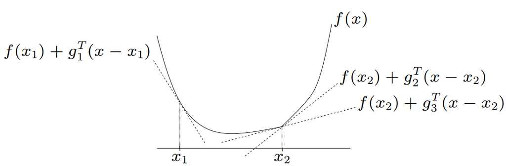

图1: 一元凸函数，在$x_1$处可微，在$x_2$处不可微。

可以看到，$f$在$x_1$处的切线将函数图像“托”在上方，虽然在$x_2$处无法定义切线，但仍然存在过$(x_2,f(x_2))$的直线“托住”图像。

因此我们称$g\in\mathbf{R}^n$是函数（不一定是凸函数）$f:\mathbf{R}^n\to\mathbf{R}$在$x\in\mathbf{dom}\ f$处的**次梯度**（*subgradient*），如果它满足
$$f(y)\ge f(x)+g^T(y-x),\ \text{for all}\ y\in\mathbf{R}^n.$$
（当$n=1$时，我们也称次梯度为**次导数**（*subderivative*））

如果函数$f$是凸函数，我们还有以下两个个结论：

- 若$x\in\mathbf{int\ dom}\ f(\text{or}\ \mathbf{relint\ dom}\ f)$，即$x$是定义域的内点（或相对内点）时，则该点的次梯度一定存在；
- 若$f$在$x$处可微，则该点次梯度唯一存在，且就是梯度$\nabla f(x)$。

函数$f$在$x$处**次微分**（*subdifferential*）定义为该点所有次梯度组成的**集合**，记为$\partial f(x)$，即
$$\partial f(x)=\{g\in\mathbf{R}^n|f(y)\ge f(x)+g^T(y-x),\ \text{for all}\ y\in\mathbf{R}^n\}$$

例如函数$f(x)=|x|$，它的图像如下

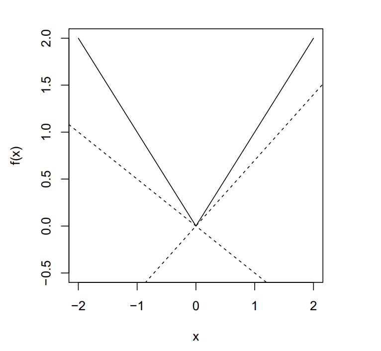

图2: f(x)=|x|

则它的次微分为
$$\partial f=
\begin{cases}
\{-1\}, & x<0 \\
[-1,1], & x=0 \\
\{1\}, & x>0
\end{cases}\$$

我们不加证明的给出次微分的几条性质

- $\partial f(x)$是闭凸集（可为空集，显然，若$f$是凸函数且$x\in\mathbf{relint\ dom}\ f$时，它是非空的）；
- 若凸函数$f$在$x$处可微，则$\partial f(x)=\{\nabla f(x)\}$；
- 若$\alpha\ge 0$，则$\partial(\alpha f)=\alpha\partial f$；
- **可加性**：$\partial(f+g)=\partial f+\partial g$（两个集合相加定义为$A+B=\{x+y|x\in A,\ y\in B\}$）。

说了这么多，我们就是为了得到下面这条重要结论：对任意函数$f$我们都有
$$f(x^*)=\min_x{f(x)}\Longleftrightarrow 0\in \partial f(x^*).\tag{3.1}$$
也就是说，$x^*$是最小值点当且仅当$0$是$f$在该点的次梯度，这也称为**次梯度极值条件**（*subgradient optimality condition*）。这很好证明，因为$0$是$f$在$x^*$处的次梯度意味着
$$f(y)\ge f(x^*)+0^T(y-x^*)=f(x^*),\ \text{for all}\ y.$$

此时我们便可以将KKT条件中的**稳定性条件**（2.2）替换为
$$0\in\partial\left(f_0(x^*)+\sum_{i=1}^{m}{\lambda_i^* f_i(x^*)}+\sum_{i=1}^{p}{\nu_i^* h_i(x^*)}\right)\tag{3.2}$$
即$0$是$L(x,\lambda^*,\nu^*)$在$x=x^*$处的次梯度。

## 3.2. 两种形式的等价性

LASSO问题本质上是一个$l_1$惩罚的问题，下文中主要讨论的是最典型的线性LASSO回归问题。我们设$y\in\mathbf{R}^n$是响应变量，假设已经过中心化处理，即
$$\sum_{i=1}^{n}{y_i}=0$$
$X=(X_1,\cdots,X_p)\in\mathbf{R}^{n\times p}$是预测变量，其中$X_j\in\mathbf{R}^n$是第$j$个变量，假设已经过标准化处理，即
$$\sum_{i=1}^{n}{X_{ij}}=0,\ \sum_{i=1}^{n}{X_{ij}^2}=1,\ \ \ j=1,\cdots,p.$$
$\beta\in\mathbf{R}^p$是待估计的系数（因为已经经过中心化处理，所以不用考虑截距项）。为了简化讨论，我们只考虑$n>p$且$\text{rank}(X)=p$的情况（即不存在多重共线性）。

LASSO估计可以定义为以下形式
$$\begin{aligned}
& \min_{\beta}\ \ {\parallel y-X\beta\parallel^2}\\
&\ \text{s.t.}\ \ \ \parallel\beta\parallel_1\le t
\end{aligned}
\tag{C}$$
其中$\parallel\beta\parallel_1=\sum_{j=1}^p{|\beta_j|}$，上式也称为**约束形式**（**C**onstrained form），我们记为问题（C）。

还有一种更常用的形式
$$\begin{aligned}
\min_{\beta}\ \ {\parallel y-X\beta\parallel^2}+\lambda\parallel\beta\parallel_1,\ \ \lambda\ge 0
\end{aligned}
\tag{L}$$
我们称上式为**拉格朗日形式**（**L**agrange form），并记为问题（L）。

大多数文献和书上都直接默认这两个问题是等价的，即**对任意$t\ge0$存在$\lambda\in[0,\infty]$使得问题（C）的解与问题（L）的解是相同的，反之也成立**[^8]。作为KKT条件的应用，我们给出一个简短的证明。

**（C）$\Rightarrow$（L）**：

很容易验证问题（C）是一个凸优化问题。我们先写出问题（C）的拉格朗日函数
$$L(\beta,\lambda)={\parallel y-X\beta\parallel^2}+\lambda(\parallel\beta\parallel_1-t)$$
先假设$t>0$，此时问题（C）是严格可行的（例如$\beta=0$就是一个严格可行解），根据Slater定理可知此问题的强对偶性是成立的。又因为$d^*=p^*\ge 0$，所以对偶问题也是可行的，因此存在$\tilde{\lambda}\ge 0$是对偶问题的最优解（见1.4节结尾）。由于强对偶成立，我们根据2.1节第一个结论，可知问题（C）的最优解$\beta^*$极小化$L(\beta,\tilde{\lambda})$，显然$\beta^*$也极小化问题（L）的目标函数（它俩之间只差个常数$-\tilde{\lambda}t$）。这就说明了：对任意$t>0$，存在某个$\lambda\ge 0$，使得问题（C）的解与问题（L）一致。若$t=0$，很容易验证问题（C）的解$\beta^*=0$也是$\lambda=+\infty$时问题（L）的解（需补充定义$0\cdot(+\infty)=0$）。

**（L）$\Rightarrow$（C）**：

类似地，如果$\beta^*$是问题（L）的最优解，我们令$\tilde{t}=\parallel\beta^*\parallel_1$，利用上面的一些结论容易验证问题（C）（此处$t=\tilde{t}$）的KKT条件是成立的（验证稳定性条件时可以使用（3.1）式），所以$\beta^*$也是问题（C）的最优解（因为问题（C）是凸问题，见2.2节后半段）。

## 3.3. LASSO解的性质

下面我们只考虑拉格朗日形式的问题（L），并记它的目标函数为
$$S(\beta)={\parallel y-X\beta\parallel^2}+\lambda\parallel\beta\parallel_1$$
其中$\lambda\ge 0$。这是一个无约束优化问题，所以KKT条件退化为次梯度极值条件（3.1）式。也就是说，若$\beta^*$极小化$S(\beta)$，则
$$\begin{align*}
& 0\in\partial S(\beta^*) \\
\Longleftrightarrow\ & 0\in -X^T(y-X\beta^*)+\lambda\partial\parallel\beta^*\parallel_1 \\
\Longleftrightarrow\ & X^T(y-X\beta^*) \in \lambda\partial\parallel\beta^*\parallel_1 \\
\Longleftrightarrow\ & X^T(y-X\beta^*)=\lambda s,\
s_i\in\begin{cases}
\{\text{sign}(\beta_i^*)\},\ &\beta_i^*\neq0\\
[-1,1],\ &\beta_i^*=0
\end{cases},\ i=1,\cdots,p \tag{3.3}
\end{align*}$$

第一个箭头用到了次微分的可加性。容易验证$S(\beta)$是关于$\beta$的严格凸函数，因此$\beta^*$是唯一的小极值点，再由（3.3）式可知$s_i$也是唯一确定的（因为$X,y$都是已知的）。我们定义**等相关集**(*equicorrelation set*)
$$E=\{j\in\{1,2,\cdots,p\}:|X_j^T(y-X\beta^*)|=\lambda\},$$
当然这个集合也是唯一确定的。而且再根据（3.3）式，我们知道如果$i\notin E$则$\beta_i^*=0$ 。也就是说，给定某个$\lambda$，则拉格朗日形式的LASSO问题（L）筛选出的变量编号一定在集合$E$中；换句话说，非零LASSO回归系数所对应的变量与残差$y-X\beta^*$的相关系数的绝对值大小是相等的[^9]，且回归系数的符号与相关系数的符号一致。上面的这个结论非常重要，它也是**最小角回归**（*Least Angle Regression*）的出发点。

# 4.总结

# 参考文献

[1] S. Boyd and L. Vandenberghe (2004), [*Convex optimization*](https://web.stanford.edu/~boyd/cvxbook/bv_cvxbook.pdf), Chapter 5

[2] R. Tibshirani (2018), Subgradients [PDF].Retrieved from http://www.stat.cmu.edu/~ryantibs/convexopt/lectures/subgrad.pdf

[3] R. Tibshirani (2018), KKT conditions [PDF].Retrieved from http://www.stat.cmu.edu/~ryantibs/convexopt/lectures/kkt.pdf

[4] R. Tibshirani (2013), [The lasso problem and uniqueness](https://projecteuclid.org/euclid.ejs/1369148600)

[5] J. Duchi, Subgradients [PDF].Retrieved from http://stanford.edu/class/ee364b/lectures/subgradients_notes.pdf

[^1]: [**仿射函数**（*affine function*）](http://mathworld.wolfram.com/AffineFunction.html) 可以简单看成一个线性函数加上一个常数，如$y=kx+b,k\neq0$，当$b=0$时为线性函数。很容易验证仿射函数既是凸函数也是凹函数。
[^2]: $\inf$（或$\min$）运算具有“保凹性”，例如$\min{(-t^2, t)}$ 还是凹函数，不同的只是这里的$\inf$ 是关于$\mathcal{D}$ 中所有$x$求极小值。如果理解困难，可以看[这里的解释](https://math.stackexchange.com/questions/1374399/why-is-the-lagrange-dual-function-concave) 。类似的，$\sup$（或$\max$）运算具有“保凸性”。
[^3]: **可行集**（*feasible set*）指的是所有可行解组成的集合，例如问题（1.1）的可行集定义为
    $$\{x\in\mathcal{D}|f_i(x) \le 0, \ i=1,\cdots,m; \ h_i(x)=0\ i=1,\cdots,p\}$$
    若可行集非空，则称该问题是**可行的**（*feasible*），否则称该问题**不可行**（*infeasible*）。
    当原问题不可行时，我们定义$p^*=+\infty$，因为我们通常记空集的下确界是正无穷；同理，若对偶问题（1.3）不可行，我们定义$d^*=-\infty$。
    当$p^*=-\infty$时，我们称原问题（1.1）**无下界**；当$d^*=+\infty$时，我们称对偶问题（1.3）**无上界**。
    根据弱对偶性，若$d^*=+\infty$（即对偶问题无上界），则必有$p^*=+\infty$（即原问题不可行）；同理，若$p^*=-\infty$（即原问题无下界），则必有$d^*=-\infty$（即对偶问题不可行）。
[^4]: 函数$f:\mathbf{R}^n\to\mathbf{R}$的**$\alpha$-下水平集**（*$\alpha$-sublevel set*）定义为$C_\alpha=\{x\in\mathbf{dom}\ f|f(x)\le \alpha \}$，容易验证凸函数的任意$\alpha$-下水平集都是凸集（反之不一定）。
[^5]: $\mathbf{relint}\ \mathcal{D}$表示$\mathcal{D}$的[**相对内部**（*relative interior*）](https://en.wikipedia.org/wiki/Relative_interior) 。可以从直观上感受一下，我们知道二维平面中的线段没有内点，但如果从一维的角度去看，它的内部就是除去端点的部分（类似于开区间），实际上它的相对内部指的就是这部分。严格的定义见上面链接，按照定义我们可以验证：单独一个点的相对内部就是这个点；内部非空的凸集的相对内部就是其内部（咋听起来像绕口令= =），当然，开集的相对内部就是其本身。
[^6]: 事实上，对于线性规划来说，只要原问题或者对偶问题其中一个可行，那么强对偶性就成立。换句话说，只有两者都不可行时强对偶性才不成立。
[^7]: 凸函数乘以非负数后还是凸函数，所以$\tilde{\lambda}_i f_i(x),\ i=1,\cdots,m$是凸函数；乘以常数后，$\tilde{\nu}_i h_i(x),\ i=1,\cdots,p$还是仿射函数，当然也是凸函数；容易证明凸函数的和还是凸函数，因此$L(x,\tilde{\lambda},\tilde{\nu})$是凸函数。
[^8]: 注意$t$与$\lambda$并不是一一对应的。例如设$\lambda=0$时问题（L）的解为$\tilde{\beta}$，即普通最小二乘解，那么只要$t\ge \parallel\tilde{\beta}\parallel_1$，则问题（C）的解也是$\tilde{\beta}$。
[^9]: 对于$j\in E$，由于$y,X$都经过标准化处理，所以$X_j$与$y-X\beta^*$的均值都为$0$，且$\mathbf{Var}(X_j)=1$，因此样本相关系数为$\frac{1}{n} X_j^T(y-X\beta^*)/\sqrt{\mathbf{Var}(X_j)\mathbf{Var}(y-X\beta^*)}=\frac{1}{n} \lambda s_j/\sqrt{\mathbf{Var}(y-X\beta^*)}$。同时可以注意到$s_j X_j$与$y-X\beta^*$的夹角也是相同的（且为锐角）。